# EDA-FRA

Hi folks.

Been trying to understand the difference across variables for default classes.

### Crude Balancing

As you know, the training dataset is imbalanced in favor of `Did Not Default`. So the dataset was, for the lack of a better term, *crudely* balanced like so:

- All `Did Default` cases were pushed into a new training set.
- The `Did Not Default` cases were picked from random from the original set.

The final set had all the `Did Default` & 700 `Did Not Default` cases.

### Data Visualization

The `Number of Dependants` seems to be less for those who did default.

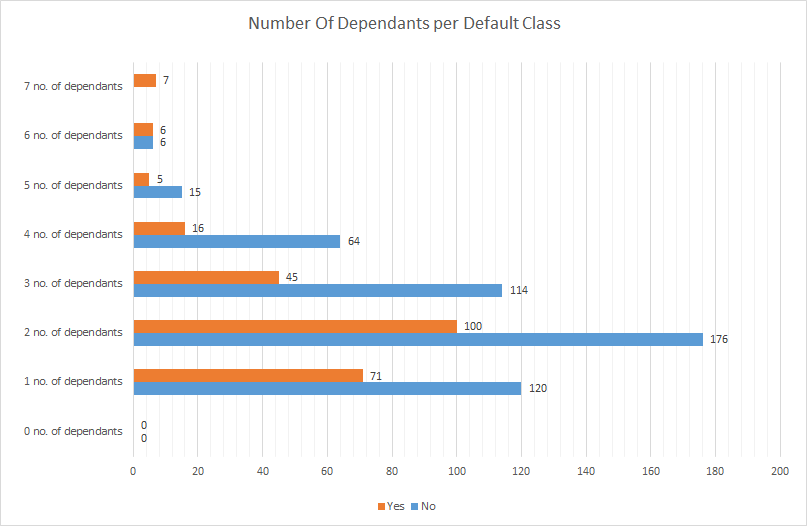

Whether this is due to imbalanced data or some other phenomenon needs to be explored.

The same can be said for `Number of Open Credit Lines & Loans`.

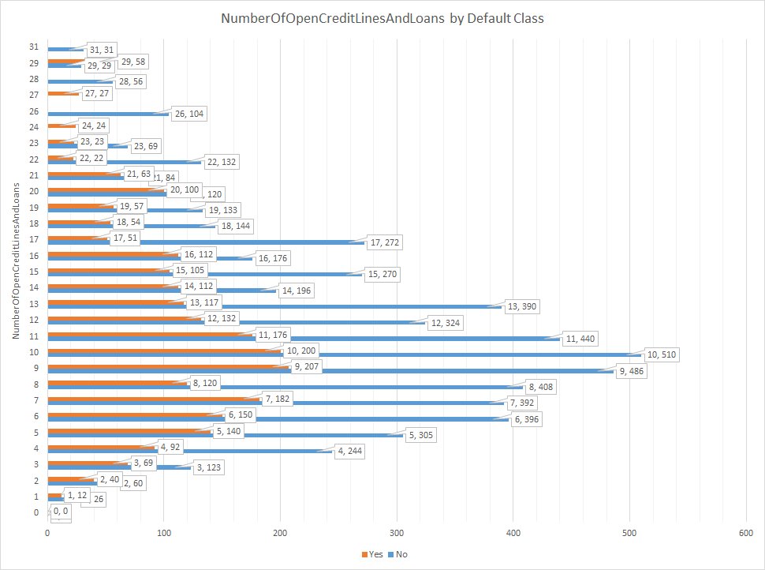

[interactive chart not shown]

[interactive chart not shown]

`Revolving Utilization Of Unsecured Lines` has extreme values way above 1. This means the total balance on credit cards and other credit lines far exceed the sum of credit limits available. This is meaningless. The data for these records is corrupt or incorrect. Either way, the records cannot be used.

Now this is done, we’ll have to see if the anomalies exist in balanced data as well.